# 2026-02-27-correlation

## Correlation Coefficient

The correlation coefficient (Pearson correlation coefficient to be exact) measures the strength and direction of linear correlation between two random variables. It is given by the ratio between their covariance and the product of their standard deviations, returning a value between -1 and 1. Unlike covariance, it is a unitless, standardized measure that is intuitively interpretable and comparable across different variable pairs that don't have the same unit.

##### $r_{xy}=\frac{s_{xy}}{s_xs_y}=\frac{\sum_{i=1}^{n}{(X_i-\bar{X})(Y_i-\bar{Y})}}{\sqrt{\sum_{i=1}^{n}{(X_i-\bar{X})^2}}\sqrt{\sum_{i=1}^{n}{(Y_i-\bar{Y})^2}}}$

The calculation is the same for samples and populations. For populations the covariance is denoted as $\sigma_{xy}$ and the standard deviations as $\sigma$ instead of sample covariance $s_{xy}$ and sample standard deviations $s$.

Population: $\rho_{xy}=\frac{\sigma_{xy}}{\sigma_x\sigma_y}$

Sample: $r_{xy}=\frac{s_{xy}}{s_xs_y}$

### Correlation does not imply Causation

The correlation coefficient between x and y is the same as between y and x: $r_{xy}=r_{yx}$.

So there is no way to distinguish between the two variables as to which is the dependent and which the independent variable. Correlation cannot be interpreted as a cause-and-effect relationship but merely as how and to what extend two variables can be associated with each other.

```python
from statistics import covariance
import numpy as np

x = np.linspace(1,10,50) + np.random.rand(50)
y = np.linspace(1,10,50) + np.random.rand(50)

covariance(x,y) / np.multiply(np.std(x, ddof=1), np.std(y, ddof=1))
```

```
np.float64(0.9894298764601888)
```

```python
from scipy.stats import pearsonr

pearsonr(x,y).statistic
```

```
np.float64(0.9894298764601889)
```

## Correlation Matrix

A correlation matrix is a table that displays the correlation coefficients between multiple variables, showing how strongly pairs of variables are related.

|  | Apple | Alphabet | Bank of America (BAC) |
| --- | --- | --- | --- |
| Apple | 1.000000 | 0.787393 | 0.255427 |
| Alphabet | 0.787393 | 1.000000 | 0.062079 |
| Bank of America (BAC) | 0.255427 | 0.062079 | 1.000000 |

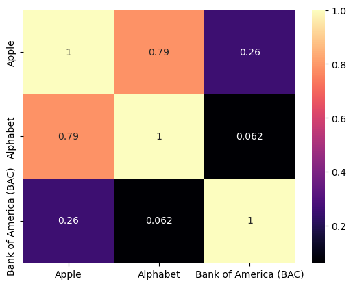

```python
import pandas as pd
import seaborn as sns

corr_matrix = pd.read_excel("stock_prices.xlsx").drop("Date", axis=1).corr("pearson")
sns.heatmap(corr_matrix, annot=True, cmap="magma")
corr_matrix
```